# A3_TeamAPP

Team APP

```r
#install.packages('corrplot')
#install.packages('RColorBrewer')
#install.packages('glmnet')
#install.packages('caret')

library(RColorBrewer)
library(corrplot)
library(glmnet)
library(caret)
# path to the Dataset
path='D:/DA/A3/'
```

#### Question 1

One of the assumptions of multiple linear regression is that there must be no multicollinearity between pairs of dependent variables

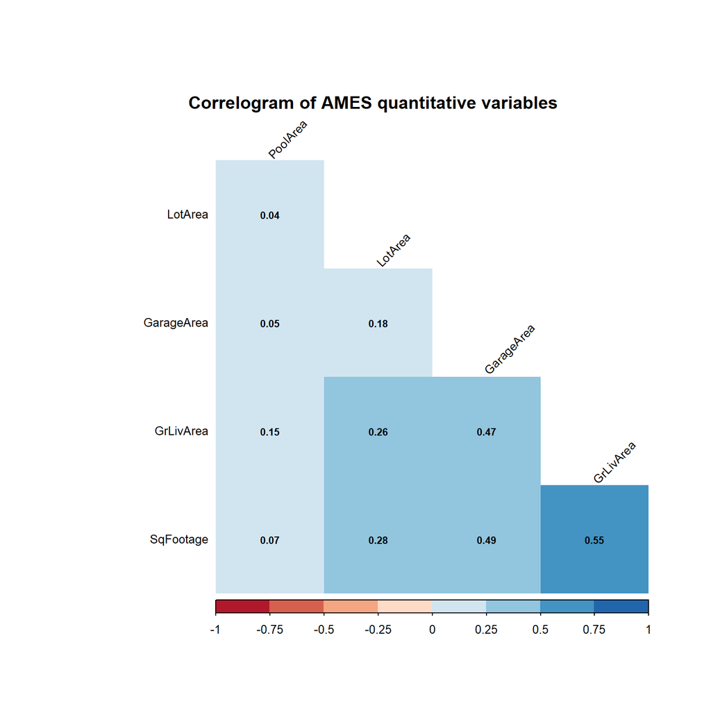

```r
train = "AmesHousingPrices/train.csv"
test = "AmesHousingPrices/test.csv"

ames_train = read.csv(paste(path,train,sep=""))
ames_test = read.csv(paste(path,test,sep=""))
#dummy = na.omit(ames_train)

ames_quantitative = ames_train[,c(3,10,19,20,22)]
drop = c("X","Id")
ames_quantitative = ames_quantitative[,!(names(ames_quantitative) %in% drop)]

#Ref: http://www.sthda.com/english/wiki/visualize-correlation-matrix-using-correlogram

#cor() reutrns a matrix of correlation values
cor_mat = cor(ames_quantitative)

#different methods of the correlation plot
methods = c("circle", "square", "ellipse", "number", "shade", "color", "pie")

#colors = colorRampPalette(c("red", "white", "blue"))(20)

plt = function(){
        corrplot(cor_mat, #matrix of correlation
        method = methods[5], #shade
        type = "lower", #lower triangular matrix only
        diag=FALSE, #exclude the diagonal
        order="hclust", #heirarchical clustering
        col = brewer.pal(n=8, name="RdBu"), #Use RColorBrewer to get a palette of blue and red gradient
        tl.col="black", #color of text
        tl.srt = 45, #tilt by 45 degrees
        addCoef.col = "black", #Add correlation coefficients in each box
        number.cex = 0.7,
        tl.cex = 0.8        )
        title(main = 'Correlogram of AMES quantitative variables', line = -2)
}

plt()
```

```r
print("The summary statistics for GrLivArea are:")
```

```
## [1] "The summary statistics for GrLivArea are:"
```

```r
summary(ames_quantitative$GrLivArea)
```

```
##    Min. 1st Qu.  Median    Mean 3rd Qu.    Max.
##     334    1125    1459    1517    1789    4676
```

```r
print("The summary statistics for SqFootage are:")
```

```
## [1] "The summary statistics for SqFootage are:"
```

```r
summary(ames_quantitative$SqFootage)
```

```
##    Min. 1st Qu.  Median    Mean 3rd Qu.    Max.
##   334.0   874.5  1085.0  1161.2  1381.5  3228.0
```

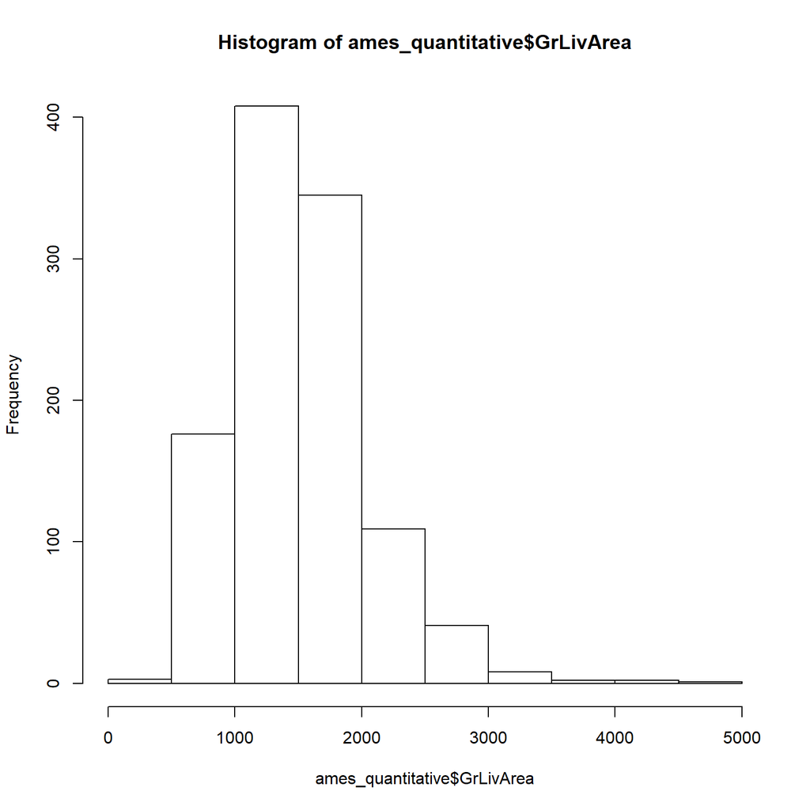

```r
hist(ames_quantitative$GrLivArea)
```

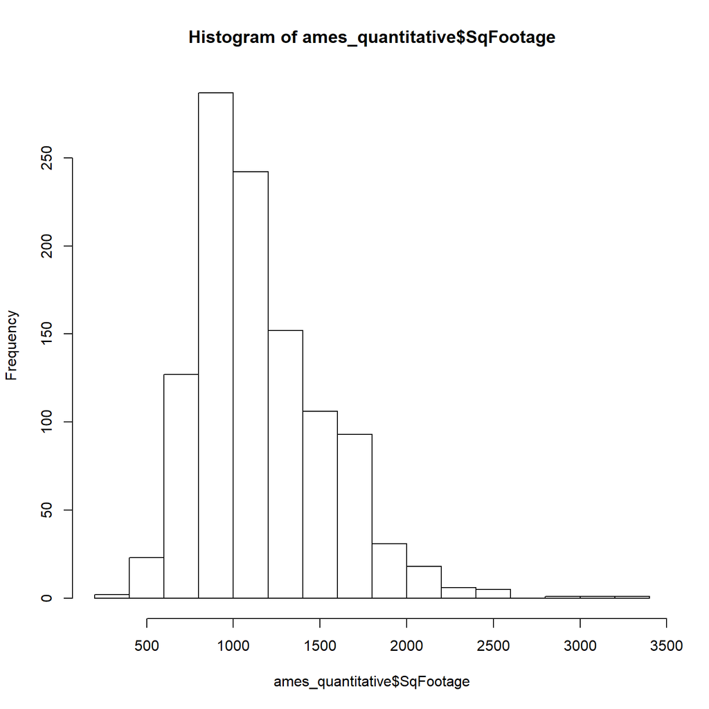

```r
hist(ames_quantitative$SqFootage)
```

```r
#corrgram(ames_quantitative, order=NULL, lower.panel=panel.shade,upper.panel=panel.pie, text.panel=panel.txt,main="Quantitative variables of AMES")
```

#### Pearson’s correlation coefficient cannot be used on categorical variables. Provide a suitable visualisation for the relationship between a categorical variable and the target variable. Plot this graph for the variable “OverallQuality” and indicate its relationship with the target “SalePrice”. Why is this variable categorical?

#### Ans. We can use a boxplot of the salesprice for each value of the categorical variable in order to check its correlation with the target variable. We can compare the values of the target variable for each value of the categorical variable using the Median, Q1, Q3, etc. In this case, as we can clearly see, higher the OverallQuality, higher the SalesPrice.

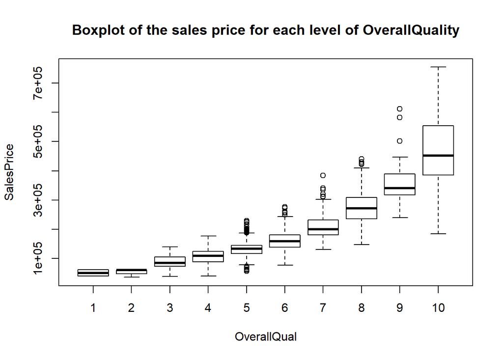

```r
qualityvalues = split(ames_train[,"SalePrice"], ames_train$OverallQual)
boxplot(qualityvalues,
        main = "Boxplot of the sales price for each level of OverallQuality",
        xlab = "OverallQual",
        ylab = "SalesPrice")
```

## Question-2

#### a)Fit a linear regression model to your data, using all of the variables you decided to keep from the previous question

```r
model <- lm(SalePrice ~ . -X -Id, ames_train)
#summary(model)
p1 <- predict(model,ames_test)
print(
        paste(
                "The RMS error of the first model on the test set is:",
                RMSE(p1 , ames_test$SalePrice)
        )
)
```

```
## [1] "The RMS error of the first model on the test set is: 41582.1677761621"
```

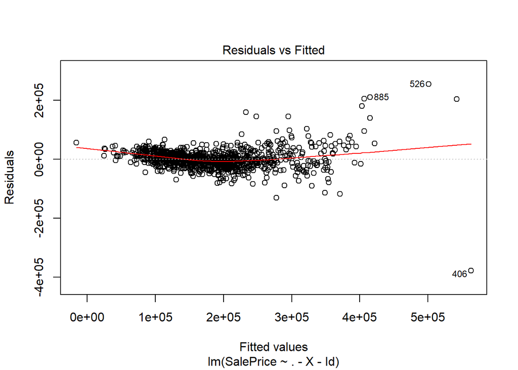

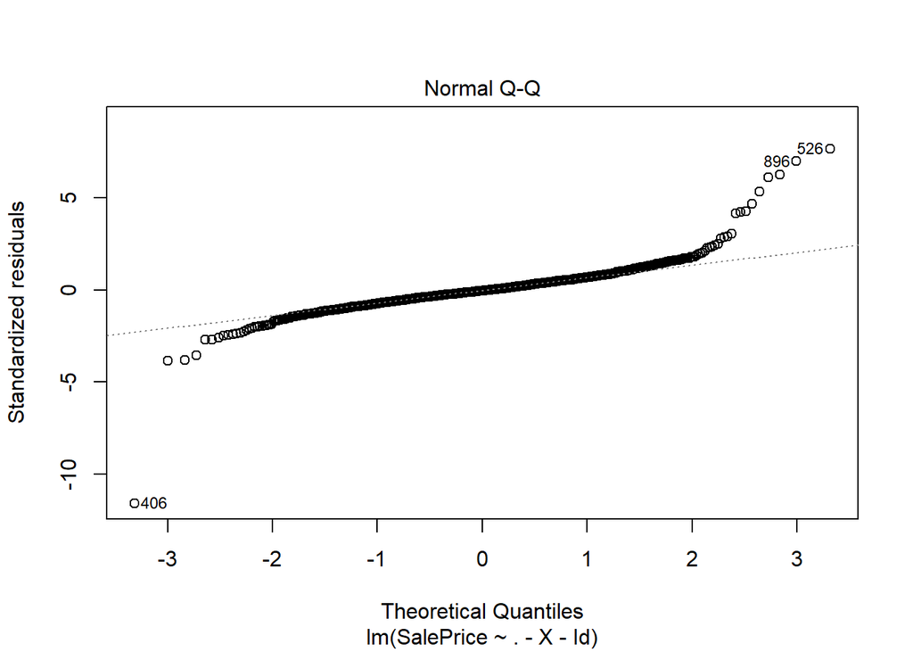

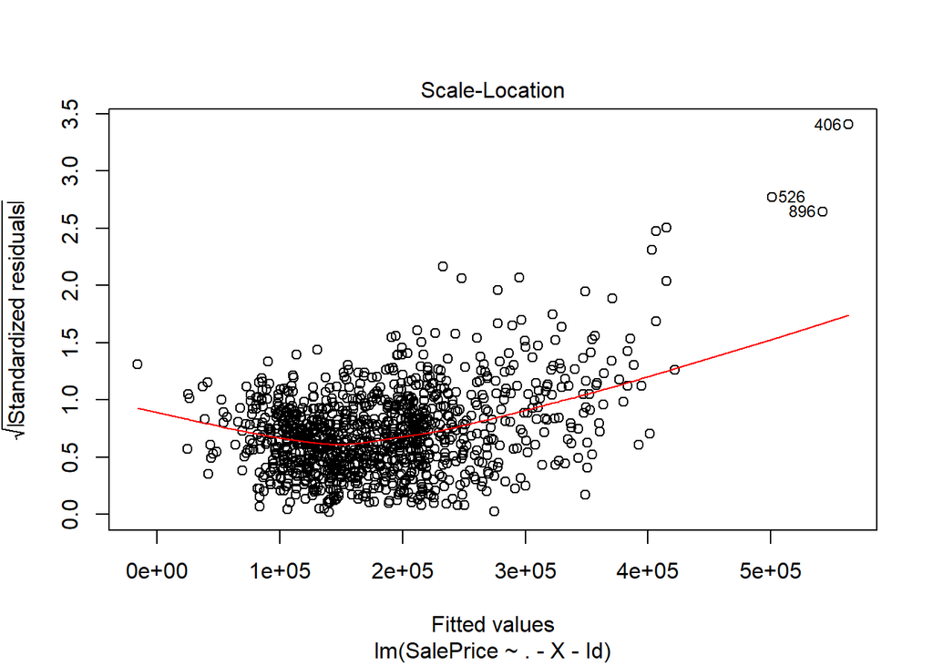

```r
plot(model, which  = c(1,2,3))
```

#### b)Plot the standardised residuals versus fitted values. What does an ideal plot of this kind look like? Which prerequisite for the application of linear regression does the plot violate?

Ans. An Ideal plot of the standardised residuals and the fitted values should be random, and must have a constant variance. But, as we see here, the Standardized residual vs fitted plot has a pattern and does not have constant variance. In order to fix this, we should use some transformation.

#### c)Use the histogram of the target variable to decide what kind of transformation you can apply to correct the problem you identified. Compare the plots of the original and corrected model

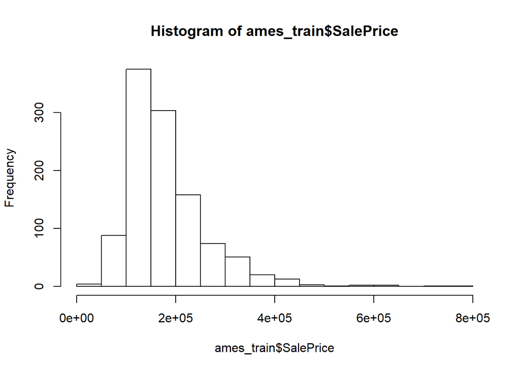

```r
hist(ames_train$SalePrice)
```

Ans: As we see, the histogram of the target variable is positively skewed. In order to fix this, we can use the log transform ation, which will make it approximately normal. After looking at the histogram plot after the transform, we can tell that it has been made normal.

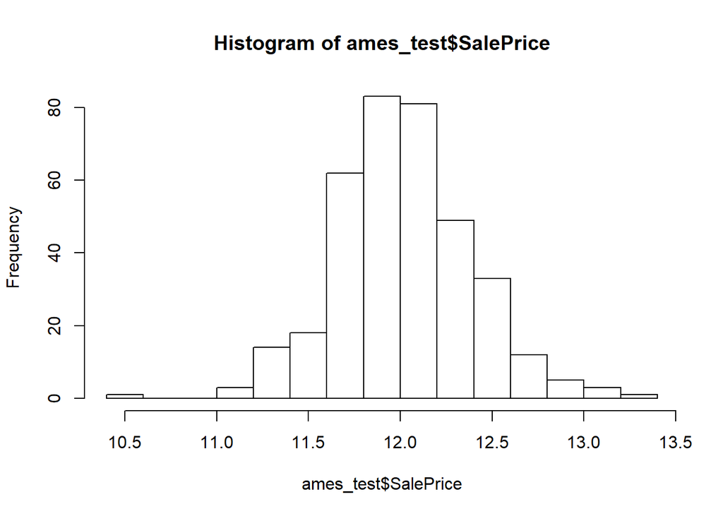

```r
ames_test[,"SalePrice"] <- log(ames_test[,"SalePrice"])
ames_train[,"SalePrice"] <- log(ames_train[,"SalePrice"])
hist(ames_test$SalePrice)
```

#### Analyse the residuals to decide whether or not they are normally distributed

Ans:AS we can see the Normal Q-Q plot, it is much better than the first model and is almost normal, except for the tails, it is very close to the ideal Q-Q plot.

```r
model2 <- lm(SalePrice ~ . -X -Id, ames_train)
#summary(model2)
p2 <- predict(model2,ames_test)
print(
        paste(
                "The RMS error of the first model on the test set is:",
                RMSE(p2 , ames_test$SalePrice)
        )
)
```

```
## [1] "The RMS error of the first model on the test set is: 0.193498734671346"
```

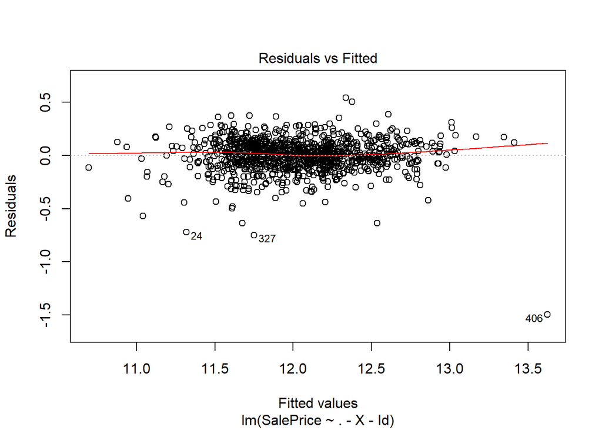

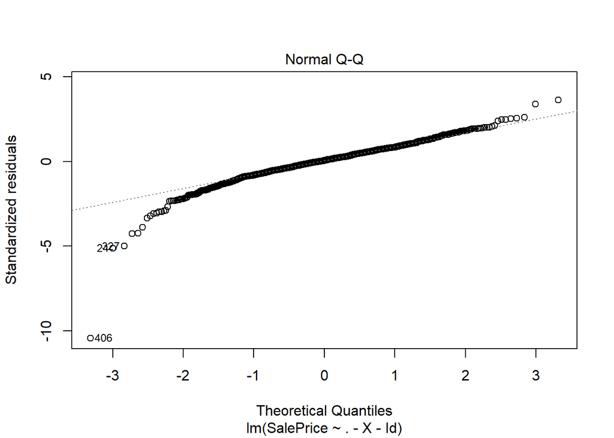

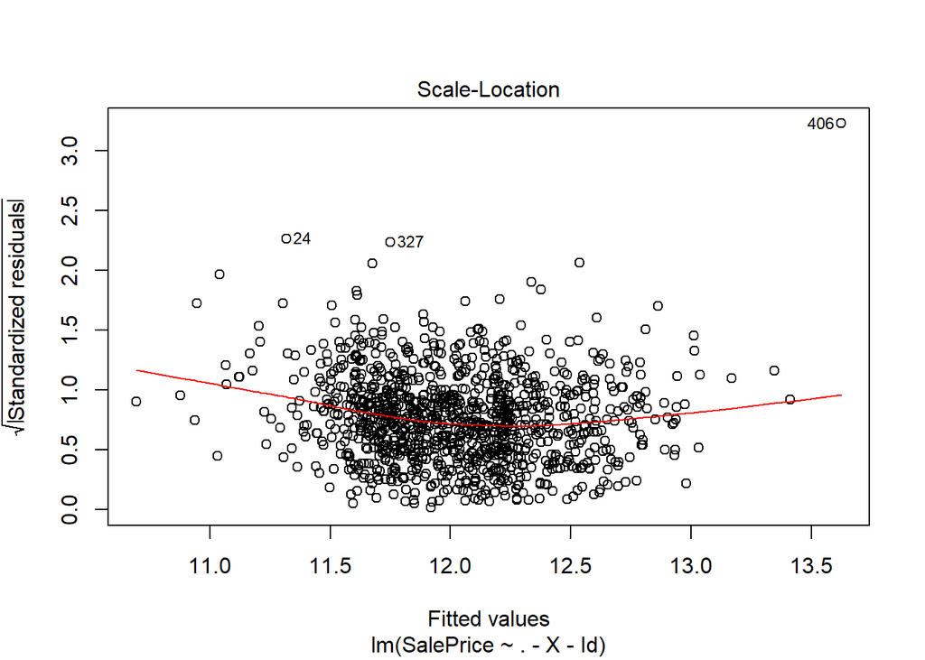

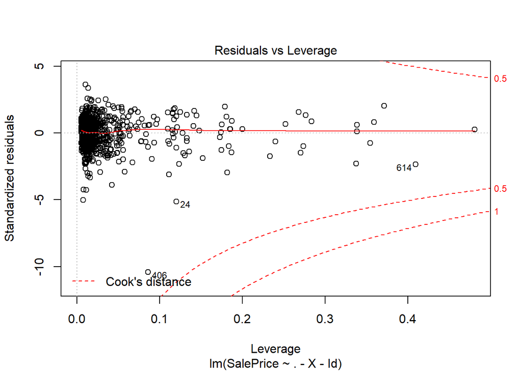

```r
plot(model2)
```

## Question-3

#### a)What does the measure R2 indicate? Is it a reliable measure of the goodness of fit of a model? Compare the R2 values for both models.

Ans. The R2 value indicates the fraction of the errors in the data that are accounted for by the model.(SSR/SST). No, R2 value is not a reliable metric in case of multiple regression, as it keeps increasing with increase in the number of attributes. A better metric would be adjusted R2 value, which also takes into account the number of attributes.

```r
print(
        paste(
                "The R2 value of the first model is:",
                summary(model)$r.squared
        )
)
```

```
## [1] "The R2 value of the first model is: 0.830419879306264"
```

```r
print(
        paste(
                "The R2 value of the second model is:",
                summary(model2)$r.squared
        )
)
```

```
## [1] "The R2 value of the second model is: 0.868074733637233"
```

#### Compute the mean absolute squared error for the two models you fit in the previous question (Make sure you account for all the transformations you carried out). Which model gives you a better MAE?

Ans. The MAE of the two models can be seen below. As we see, the second model that uses transformed Target variable is marginally better than the first one, in terms of the MAE’s wrt. the test set.

```r
p1 <- predict(model, ames_test)
p2<- predict(model2, ames_test)
p2<- exp(1) ^ p2
print(
        paste(
                "The MAE of the first Model is:",
                MAE(p1, ames_test$SalePrice)
        )
)
```

```
## [1] "The MAE of the first Model is: 180858.838321112"
```

```r
print(
        paste(
                "The MAE of the first Model is:",
                MAE(p2, ames_test$SalePrice)
        )
)
```

```
## [1] "The MAE of the first Model is: 180321.635202315"
```

## Question-4

#### a)When would you typically use Regularisation?

Ans. We typically use regularization when our model has fit the training data too well and fails to generalize, and doesnt perform well on test set. In such cases, the bias is Low , but the variance is high. In oder to fix this, we introduce some bias to decrease the variance of the model. THis way, the model performs better on the test set as well.

#### Build a model using the training set to predict the attribute SalePrice using Ridge Regression. Use the test set to evaluate the model by computing R2 and RMSE

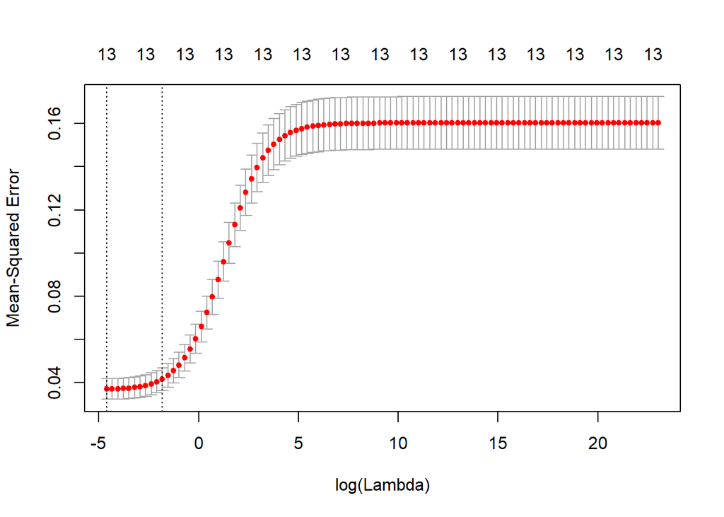

```r
train = "ShenzhenHousingPrices/train.csv"
test = "ShenzhenHousingPrices/test.csv"

shen_train = read.csv(paste(path,train,sep=""))
shen_test = read.csv(paste(path,test,sep=""))

#dummy = na.omit(shen_train)
drop = c("SalePrice")

X_train = data.matrix(shen_train[,!(names(shen_train) %in% drop)])
y_train = subset(shen_train,select = drop)
y_train = data.matrix(log(y_train))

X_test = data.matrix(shen_test[,!(names(shen_test) %in% drop)])
y_test = subset(shen_test,select = drop)
y_test = data.matrix(log(y_test))

grid = 10^seq(10, -2, length = 100)

ridge_mod = glmnet(X_train, y_train, alpha = 0, lambda = grid)

cv_fit <- cv.glmnet(X_train, y_train, alpha = 0, lambda = grid)
plot(cv_fit)
```

```r
best_lambda = cv_fit$lambda.min
print(paste("Best lambda: ",best_lambda,sep=""))
```

```
## [1] "Best lambda: 0.01"
```

```r
p = predict(ridge_mod,s = best_lambda, newx = X_test)
print(paste("RMSE: ",RMSE(p , y_test),sep=""))
```

```
## [1] "RMSE: 0.180757761150673"
```

```r
print(paste("R2: ",R2(p , y_test),sep=""))
```

```
## [1] "R2: 0.794465840719046"
```

#### c)Build another model using the training set to predict the attribute SalePrice using Lasso Regression. Use the test set to evaluate the model by computing R 2 and RMSE

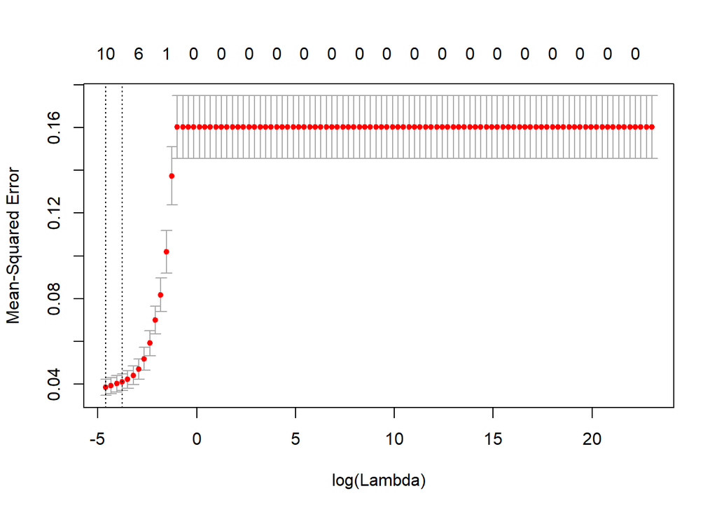

```r
lasso_mod = glmnet(X_train, y_train, alpha = 1, lambda = grid)

cv_fit <- cv.glmnet(X_train, y_train, alpha = 1, lambda = grid)
plot(cv_fit)
```

```r
best_lambda = cv_fit$lambda.min
print(best_lambda)
```

```
## [1] 0.01
```

```r
print(paste("Best lambda: ",best_lambda,sep=""))
```

```
## [1] "Best lambda: 0.01"
```

```r
p = predict(lasso_mod,s = best_lambda, newx = X_test)
print(paste("RMSE: ",RMSE(p , y_test),sep=""))
```

```
## [1] "RMSE: 0.188382281581291"
```

```r
print(paste("R2: ",R2(p , y_test),sep=""))
```

```
## [1] "R2: 0.778117156328336"
```

#### d)How do Ridge and Lasso Regression differ from each other?

Ans. The OLS algorithm for linear regression has no bias but can suffer from a large variance. Both ridge and lasso regression introduce some bias to reduce this variance. Both of these are regularised linear regression models. However, there are a few key differences between them.

- Lasso regression uses L1 norm whereas ridge regression uses L2 norm.
- Lasso regression can set the value of coefficients to zero while Ridge regression sets it to a small value. Hence, Lasso regression acts as a feature selector.
- Ridge regression is more stable to rotation while Lasso regression is not.